# Prognose-, Konfidenz- und Fiduzialintervalle

Norman Markgraf

2018-01-04

***WORK IN PROGRESS** Dieser Eintrag ist noch nicht fertig und wird in der Zukunft erweitert!

## Konfidenzintervalle

### Definition von Konfidenzintervallen[^1]

Für unabhängig identisch verteilte Zufallsvariablen $X_1,\dotsc, X_n$ mit unbekanntem reellen Verteilungsparameter $\vartheta$ kann unter bestimmten Umständen zwei Stichprobenfunktionen $U$ und $V$ angeben, so dass

$$P(U < \vartheta < V) \geq \gamma$$

gilt, mit $\gamma \in (0,1)$. Dann heißt das (stochastische) Intervall $[U, V]$ ein **Konfidenzintervall** für $\vartheta$ zum Konfidenzniveau $\gamma$ (auch: ein **$\gamma$-Konfidenzintervall**).

Die Realisationen $u$ und $v$ von $U$ bzw. $V$ bilden das **Schätzintervall** $[u, v]$.

Da die Realisationen $u$ und $v$ der Grenzen $U$ und $V$ keine Zufallsvariablen sind und $\vartheta$ ein fixer Wert ist, kann man **nicht** sagen, dass das Schätzintervall $[u, v]$ mit einer Wahrscheinlichkeit von $\gamma$ den unbekannten Parameter $\vartheta$ enthält. Es bedeutet vielmehr, dass im Mittel ein Anteil von $\gamma$ aller so berechneten Schätzintervalle den unbekannten Parameter überdecken. Dem nicht widersprechend, kann –- wie bereits von Ronald Fisher festgestellt – in manchen Modellen die Qualität des Schätzintervalls von den Daten abhängen und sogar zu Antworten führen, die mit Blick auf die Daten unsinnig sind. Probleme mit solcher Post-Data-Inkohärenz führen zur Theorie der bedingten Inferenz. Ein weiteres Problem sind die Stichprobenfunktionen U und V an sich. Um diese zu finden werden oft Vereinfachungen getroffen, dadurch können systematische Fehler entstehen, oft es gibt mehrere Konfidenzintervalle (bei der Binomialverteilung z.B. nach Clopper-Pearson, Agresti-Coull oder Wald), welche oft unterschiedliche Werte liefern.

### Ein Beispiel

Wir nehmen zunächst als Population $N=1000$ normalverteilte Zufallszahlen mit dem Mittelwert $\mu= 0$ und der Standardabweichung $\sigma=2.0088$.

Dazu das Histogramm der Population:

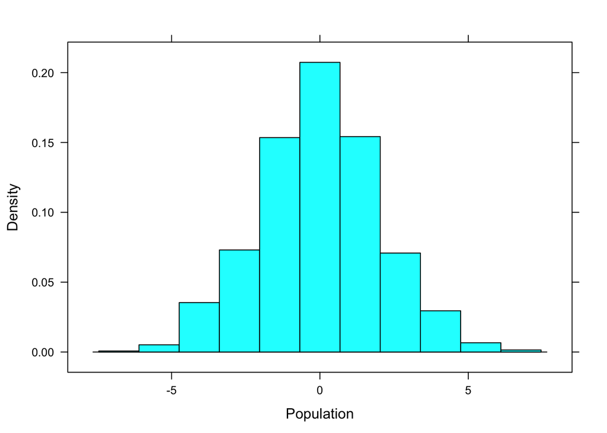

```r
histogram(pop, xlab="Population")
```

Aus dieser Population ziehen wir eine Stichprobe $x$ vom Umfang $n=$40 und erhalten die folgenden statistischen Daten:

```r
favstats(x)
```

```
##     min     Q1  median     Q3   max    mean    sd  n missing
##  -4.997 -1.052 -0.3928 0.8211 3.295 -0.3423 1.878 40       0
```

Wir wollen nun den wahren Mittelwert $\vartheta=\mu$ mit Hilfe der Stichprobe $x$ schätzen. So ist es ja in der Realität auch, denn normalerweise haben wir die Daten über die Population nicht.

Die Schätzfunktion für den Mittelwert lautet nun
$$\bar{X} = \frac1n \sum_{i=1}^n X_i$$
, und damit die konkrete Punktschätzung
$$\hat{\mu}=\bar{x}= \sum_{i=1}^n x_i$$
liefert den Wert $\hat{\mu}=$ -0.3423.

In unserem Beispiel unterscheiden sich die beiden Werte um $\mu - \hat{\mu}=$ 0.3423.

Ein 95%-Konfidenzintervall nimmt nun den geschätzen Wert $\hat{\mu}$ als Grundlage und gibt liefert ein Intervall mit der Eigentschaft, ausgehend von den konkreten Stichproben in 95% der Fälle den tatsächlichen Wert $\mu$ zu umfassen. Es ist also
$$\gamma = 0.95 = 1 - \alpha = 1 - 0.05, \quad \alpha = 0.05$$

Dazu werden die beiden Stichprobenfunktionen

$$U=U(X_1, \dots, X_n)=\bar{X}-z_{\left(1-\frac{\alpha}{2}\right)}\cdot\frac{\sigma}{\sqrt{n}}$$

mit der *bekannten* Standardabweichung $\sigma$ der *Population* und der Stichprobengröße $n$ nun mit der konkreten Realisation $x_1, \dots, x_n$ der Stichprobe gefüttert und wir erhalten damit

$$u = \bar{x}-z_{\left(1-\frac{\alpha}{2}\right)}\cdot\frac{\sigma}{\sqrt{n}} = -0.3423-z_{\left(0.975\right)}\cdot\frac{2.0088}{\sqrt{40}}=-0.9648$$
und

$$v = \bar{x}+z_{\left(1-\frac{\alpha}{2}\right)}\cdot\frac{\sigma}{\sqrt{n}} = -0.3423+z_{\left(0.975\right)}\cdot\frac{2.0088}{\sqrt{40}}=0.2803.$$

Die Realisation unseres 95%-Konfidenzintervall lautet nun also:

$$[-0.9648; 0.2803]$$

**Was hat es nun mit den ominösen 95% auf sich?**

Das Konfidenzintervall ist ein stochastisches Intervall, d.h. die hier angegebenen Werte für $u$ und $v$ sind abhängig von der Realisation $x_1, \dots, x_n$, also der konkreten Stichprobe.

Nehmen wir nun also einmal eine neue Stichprobe und berechnen erneut die Realisation unseres 95%-Konfidenzintervalls, so erhalten wir:

$$[-0.8459; 0.3992]$$

```
## Interval coverage:
```

```
##     cover
## n     Low  Yes High
##   40 0.03 0.95 0.02
```

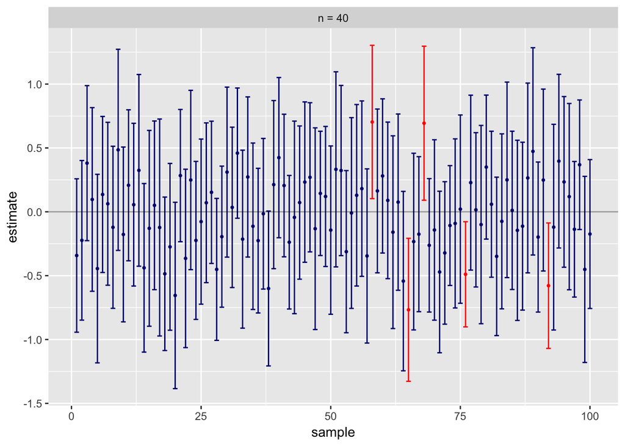

## Fuduzialintervalle

Quellen:

- Logik in der Statistik; Andrea Wiencierz, 7.10.2007 Link: https://static.aminer.org/pdf/PDF/000/230/772/induktive_inferenz_und_mehrwertige_logik.pdf
[^1]: vgl: https://de.wikipedia.org/wiki/Konfidenzintervall